# Parole Data Problem

The parole dataset poses a unique challenge to delve into.From the given details that we know about the parolee like age, race, sex, state, sentence servered, crime type and number offences committed; can we predict accurately if a parolee is likely to violate his/her parole? We shall build a Logistic Regression model and a Tree model to predict the outcome of a parolee violating a parole given certain predictor variables.

The Parole dataset has the following fields:

[output not shown]

Set the location of the dataset on local system

```r
setwd('/Users/Ameet/Box Sync/Ameet/GitHub/R-Projects/parole')
```

Read the file into memory as a dataframe to conduct analysis.

```r
parole= read.csv("parole.csv")
```

### Data Preparation Phase

In this phase, we review the parole data structure and make the necessary changes to conduct data analysis. A lot of the data is provided as integer values. Since this data is of categorical type, it makes more sense to convert it to a readable format. E.g. The male variable has values 0 and 1 to represent male or female. We shall update this to text values male/female.

Review the data variables

```r
names(parole)
```

```
[1] "male"              "race"              "age"               "state"             "time.served"
[6] "max.sentence"      "multiple.offenses" "crime"             "violator"
```

Review the range, mean and median for each variable of the dataset. This should give an initial insight about the variables in the dataset. E.g. The median age of a parolee is 33.70 and average is 34.51

```r
summary(parole)
```

```
      male             race            age            state        time.served     max.sentence
 Min.   :0.0000   Min.   :1.000   Min.   :18.40   Min.   :1.000   Min.   :0.000   Min.   : 1.00
 1st Qu.:1.0000   1st Qu.:1.000   1st Qu.:25.35   1st Qu.:2.000   1st Qu.:3.250   1st Qu.:12.00
 Median :1.0000   Median :1.000   Median :33.70   Median :3.000   Median :4.400   Median :12.00
 Mean   :0.8074   Mean   :1.424   Mean   :34.51   Mean   :2.887   Mean   :4.198   Mean   :13.06
 3rd Qu.:1.0000   3rd Qu.:2.000   3rd Qu.:42.55   3rd Qu.:4.000   3rd Qu.:5.200   3rd Qu.:15.00
 Max.   :1.0000   Max.   :2.000   Max.   :67.00   Max.   :4.000   Max.   :6.000   Max.   :18.00
 multiple.offenses     crime          violator
 Min.   :0.0000    Min.   :1.000   Min.   :0.0000
 1st Qu.:0.0000    1st Qu.:1.000   1st Qu.:0.0000
 Median :1.0000    Median :2.000   Median :0.0000
 Mean   :0.5363    Mean   :2.059   Mean   :0.1156
 3rd Qu.:1.0000    3rd Qu.:3.000   3rd Qu.:0.0000
 Max.   :1.0000    Max.   :4.000   Max.   :1.0000
```

How many are parole violators in the sample data? Out of the 675 parolees 78 violated their parole

```r
table(parole$violator)  # how many are violators
```

```
  0   1
597  78
```

Converting non-metric variables to factor:

```
Convert male variable from 0,1 to women and men

Convert race variable from 1,2 to White and 'Not White'

Convert state variable from 1,2,3,4 to Other, Kentucky, Louisiana  and Virginia

Convert crime variable from 1,2,3,3 to Other, Larceny, drug and driving

Convert multiple.offences variable from 0,1 to no and yes
```

```r
parole$male = factor(parole$male,
                     levels = c(0,1),
                     labels = c("women", "men"))
parole$race = factor(parole$race,
                     levels=c(1,2),
                     labels=c("White","Not White"))
parole$state = factor(parole$state,
                      levels = c(1,2,3,4),
                      labels = c("Other","Kentucky","Louisiana","Virginia"))
parole$crime = factor(parole$crime,
                      levels = c(1,2,3,4),
                      labels=c("Other","Larceny","drug","driving"))
parole$multiple.offenses = factor(parole$multiple.offenses,
                                  levels = c(0,1),
                                  labels = c("no", "yes"))
```

To build a statistical model and test it, we first split the given data into training and testing data sets. The statistical model will be built on the training data and tested on testing data. This approach will allow us to assess the accuracy of the statistical model. The data split ratio is training: 70% and testing: 30%.

```r
library(caTools)
set.seed(199)
split = sample.split(parole$violator,SplitRatio=0.7)
train = subset(parole,split==TRUE)
test = subset(parole,split==FALSE)
```

We now have 473 records to train the model and 202 records to test it on.

```r
nrow(train)
```

```
[1] 473
```

```r
nrow(test)
```

```
[1] 202
```

### Exploratory data analysis

This completes the data preparation phase. In the Exploratory data phase we will explore the data visually to get a better understanding of it.

##### 1) Sex: Men have a higher violation rate compared to women

```r
library(ggplot2)
tapply(train$violator,train$male,mean)
```

```
    women       men
0.0952381 0.1208226
```

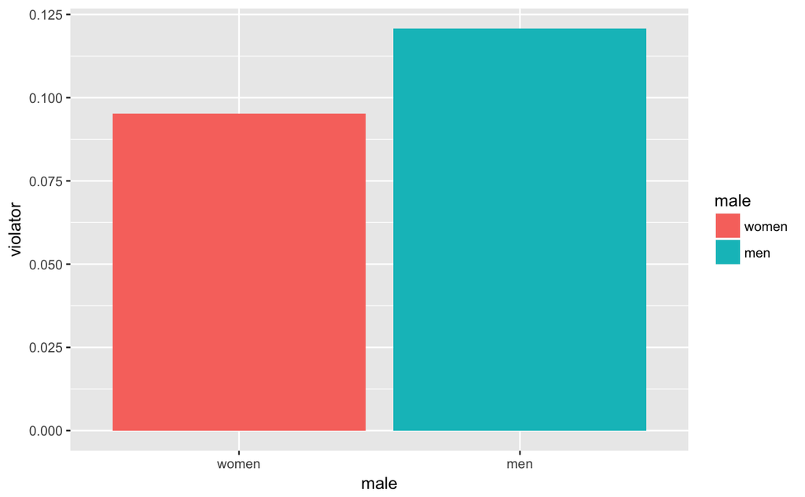

```r
ggplot(data=train,aes(x=male,y=violator,fill=male)) + geom_bar(stat='summary',fun.y='mean')
```

##### 2) Race: Non white race have a higher violation rate compared to white

```r
tapply(train$violator,train$race,mean)
```

```
     White  Not White
0.08960573 0.15463918
```

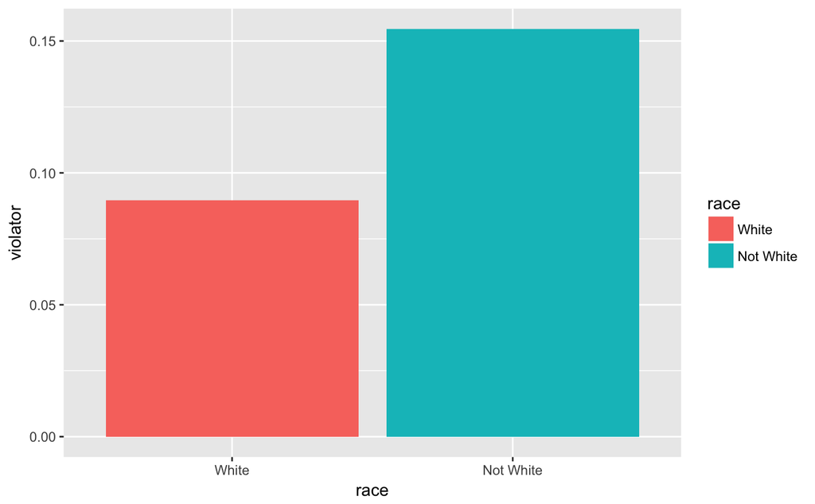

```r
ggplot(data=train,aes(x=race,y=violator,fill=race)) + geom_bar(stat='summary',fun.y='mean')
```

##### 3) Age: Average Age of violator parolee is slightly lesser than non-violator parolee

```r
tapply(train$age,train$violator,mean)
```

```
       0        1
34.64163 33.66182
```

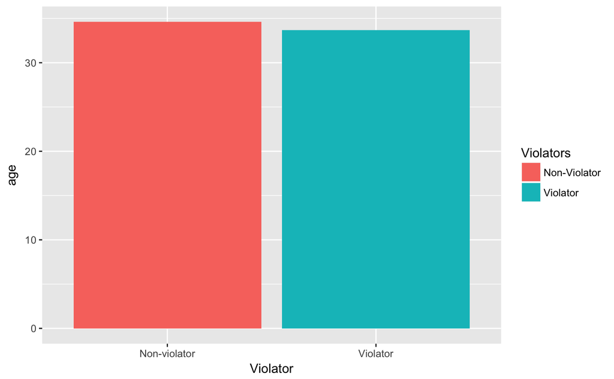

```r
ggplot(data=train,aes(x=factor(violator),y=age,fill=factor(violator)))+geom_bar(stat='summary',fun.y='mean')+
  xlab('Violator') + scale_x_discrete(labels=c("0" = "Non-violator", "1" = "Violator"))+
  scale_fill_discrete(name="Violators", breaks=c('0', '1'),labels=c('Non-Violator', 'Violator'))
```

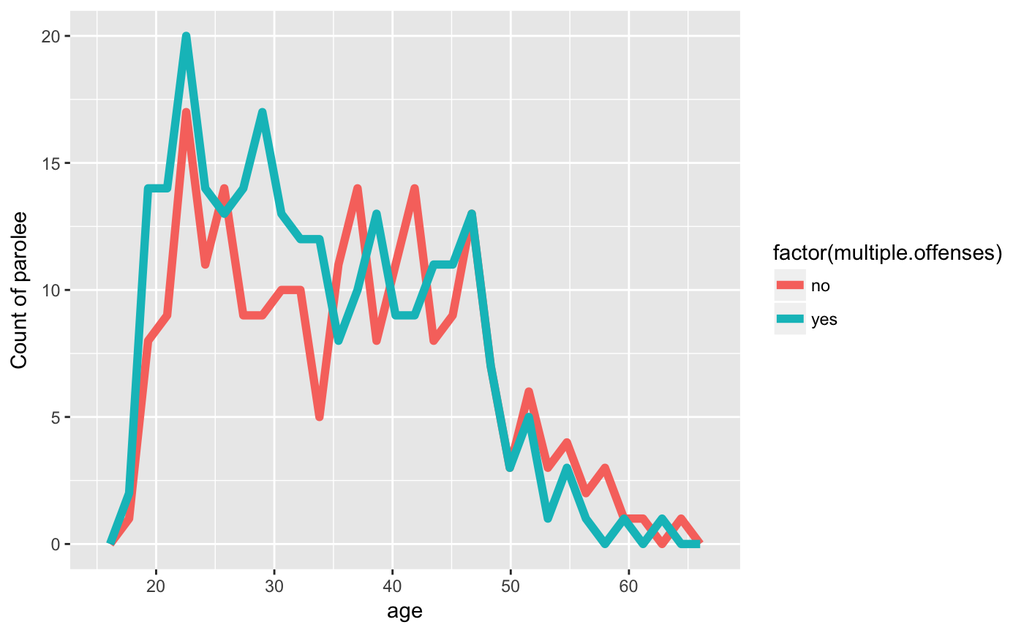

```r
ggplot(data=train,aes(x=age,color=factor(multiple.offenses)))+geom_freqpoly(size=2) + ylab('Count of parolee')
```

##### 4) State: Louisiana state has the highest violators

```r
tapply(train$violator,train$state,mean)
```

```
     Other   Kentucky  Louisiana   Virginia
0.13402062 0.08045977 0.52727273 0.02564103
```

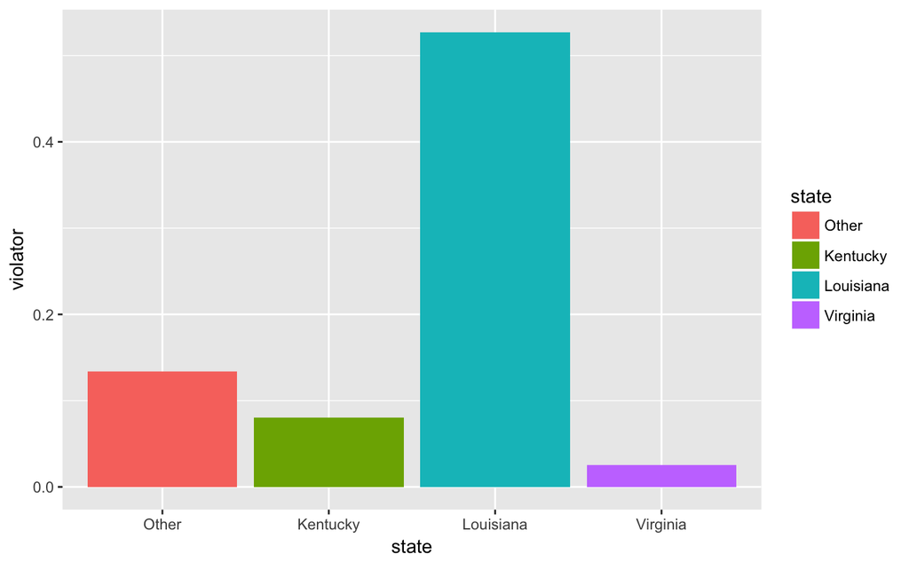

```r
ggplot(data=train,aes(x=state,y=violator,fill=state))+geom_bar(stat='summary',fun.y='mean')
```

##### 5) Time.served: Violators have served lesser time in prison than non-violators

```r
tapply(train$time.served,train$violator,mean)
```

```
       0        1
4.284211 3.838182
```

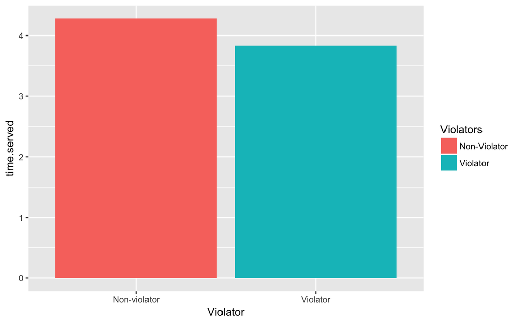

```r
ggplot(data=train,aes(x=factor(violator),y=time.served,fill=factor(violator)))+geom_bar(stat='summary',fun.y='mean')+ xlab('Violator') + scale_x_discrete(labels=c("0" = "Non-violator", "1" = "Violator"))+
  scale_fill_discrete(name="Violators",breaks=c('0', '1'),labels=c('Non-Violator', 'Violator'))
```

### Data Modeling Phase

In this phase, we create statistical models on the training data set and then test it on the test data set. We calculate certain measures like Accuracy, Specificity and Sensitivity to check the efficacy of the statistical model. We plot the ROC (Receiver Operating Characteristic) curve to illustrate the performance of the binary classifier system on various thresholds. First we create the Logistic Regression model with violator as the target variable and all other variables as the predictor variables

```r
model1 = glm(violator~.,train,family="binomial")
```

what is the interpretation of coefficient of “multiple.offenses”? “multiple.offenses” has p value <.01 showing strong co-relation.

```r
summary(model1)
```

```
Call:
glm(formula = violator ~ ., family = "binomial", data = train)

Deviance Residuals:
    Min       1Q   Median       3Q      Max
-1.9150  -0.3560  -0.2735  -0.1542   2.7166

Coefficients:
                       Estimate Std. Error z value Pr(>|z|)
(Intercept)          -3.0139190  1.2626472  -2.387   0.0170 *
malemen               0.0525724  0.4756904   0.111   0.9120
raceNot White         0.8850912  0.4053074   2.184   0.0290 *
age                   0.0001209  0.0171115   0.007   0.9944
stateKentucky        -0.0991675  0.5475179  -0.181   0.8563
stateLouisiana        1.2323271  0.5444114   2.264   0.0236 *
stateVirginia        -3.2712902  0.6283830  -5.206 1.93e-07 ***
time.served          -0.0740027  0.1259952  -0.587   0.5570
max.sentence          0.0664375  0.0580312   1.145   0.2523
multiple.offensesyes  1.7818104  0.4120608   4.324 1.53e-05 ***
crimeLarceny         -0.2809962  0.5481012  -0.513   0.6082
crimedrug            -0.6307083  0.4659698  -1.354   0.1759
crimedriving         -0.5767495  0.6274620  -0.919   0.3580
---
Signif. codes:  0 ‘***’ 0.001 ‘**’ 0.01 ‘*’ 0.05 ‘.’ 0.1 ‘ ’ 1

(Dispersion parameter for binomial family taken to be 1)

    Null deviance: 340.04  on 472  degrees of freedom
Residual deviance: 228.59  on 460  degrees of freedom
AIC: 254.59

Number of Fisher Scoring iterations: 6
```

```r
exp(model1$coefficient['multiple.offensesyes'])
```

```
multiple.offensesyes
            5.940602
```

```r
varCoefficients = c(model1$coefficient[1:13]) # list of all coefficients from model
varScores = c(1,1,1,50,0,0,0,3,12,0,1,0,0)    # list of all var based on above description
logOdds = sum(varCoefficients*varScores)      # log odds is equal to sum of product of coeffs and var scores
```

Odds of being a violator:

```r
oddsOfBeingAViolator = exp(logOdds); oddsOfBeingAViolator
```

```
[1] 0.1693197
```

Probability of being a violator: There is a 14.5% chance that this person will be a repeat violator

```r
probabilityViolator = 1/(1+exp(-logOdds));probabilityViolator
```

```
[1] 0.1448019
```

Now that we created the statistical model and tested it on the training data set, let us run it against the test dataset and see how well it performs. Applying predictions to the test sample

```r
predictTest = predict(model1,test,type="response")
```

What is the max predicted probability?

```r
max(predictTest)
```

```
[1] 0.8493585
```

##### Confusion matrix, Accuracy, Specificity and Sensitivity

Construct a Classification table or Confusion matrix using 0.5 threshold (cutoff)

```r
cMatrix = table(test$violator,predictTest>0.50); cMatrix
```

```
    FALSE TRUE
  0   165   14
  1    16    7
```

Accuracy :Higher the value, more accurate the statistical model This model has 85% accuracy rate.

```r
accuracy = sum(cMatrix[1,1],cMatrix[2,2])/nrow(test); accuracy
```

```
[1] 0.8514851
```

Specificity -> True Negative/ (True Negative+ False Positive)

Sensitivity -> True Positive/ (False negative _ True Positive)

```r
specificity = cMatrix[1,1]/sum(cMatrix[1,1],cMatrix[1,2]); specificity
```

```
[1] 0.9217877
```

```r
sensitivity = cMatrix[2,2]/sum(cMatrix[2,1],cMatrix[2,2]); sensitivity
```

```
[1] 0.3043478
```

To check the performance of the model for different cutoff values, we increase the threshold to .70.

Specificity is important as False Positives are costly errors for this data. For high specificity, threshold should be set high.

Accuracy: 87%

Specificity: 96%

Sensitivity:17%

```r
x = table(test$violator,predictTest>0.70);x
```

```
    FALSE TRUE
  0   172    7
  1    19    4
```

```r
accuracy = sum(x[1,1],x[2,2])/nrow(test); accuracy
```

```
[1] 0.8712871
```

```r
specificity = x[1,1]/sum(x[1,1],x[1,2]); specificity
```

```
[1] 0.9608939
```

```r
sensitivity = x[2,2]/sum(x[2,1],x[2,2]); sensitivity
```

```
[1] 0.173913
```

##### ROC Curves

ROC curves allow us to visualize the impact of different thresholds on Specificity and Sensitivity. Area Under Curve (AUC) is model performance measure that is independent of any particular threshold.

High threshold => Higher specificity and Lower sensitivity

Low threshold => Lower specificity and higher sensitivity

```r
library(ROCR)
ROCRpred1 = prediction(predictTest,test$violator)
as.numeric(performance(ROCRpred1,"auc")@y.values) # auc measure
```

```
[1] 0.7947535
```

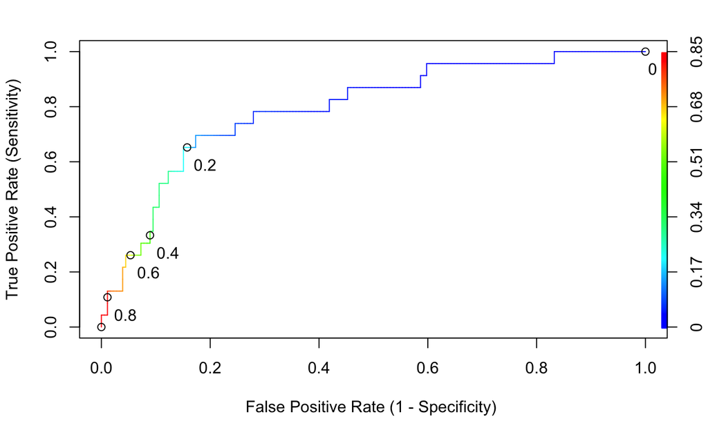

```r
ROCRperf1 = performance(ROCRpred1,"tpr","fpr")
plot(ROCRperf1,colorize=TRUE,print.cutoffs.at=seq(0,1,0.2),text.adj=c(-0.3,2),xlab="False Positive Rate (1 - Specificity) ",ylab="True Positive Rate (Sensitivity)") # color coded and annotated ROC curve
```

##### Compare Logistic Regression model to a Tree model

How will this compare to a tree model?

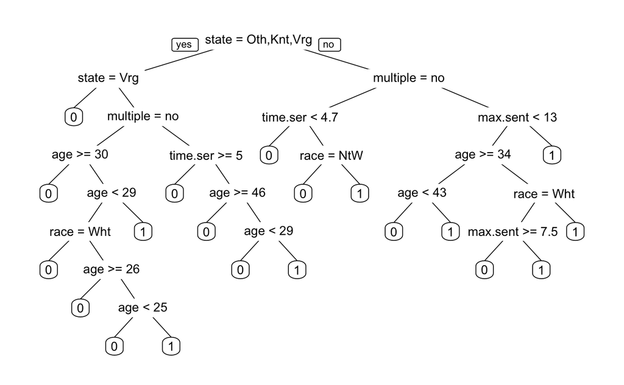

```r
library(rpart)
library(rpart.plot)
library(rattle)
tree = rpart(violator~.,data=train,method="class",control=rpart.control(minbucket=2))
prp(tree)
```

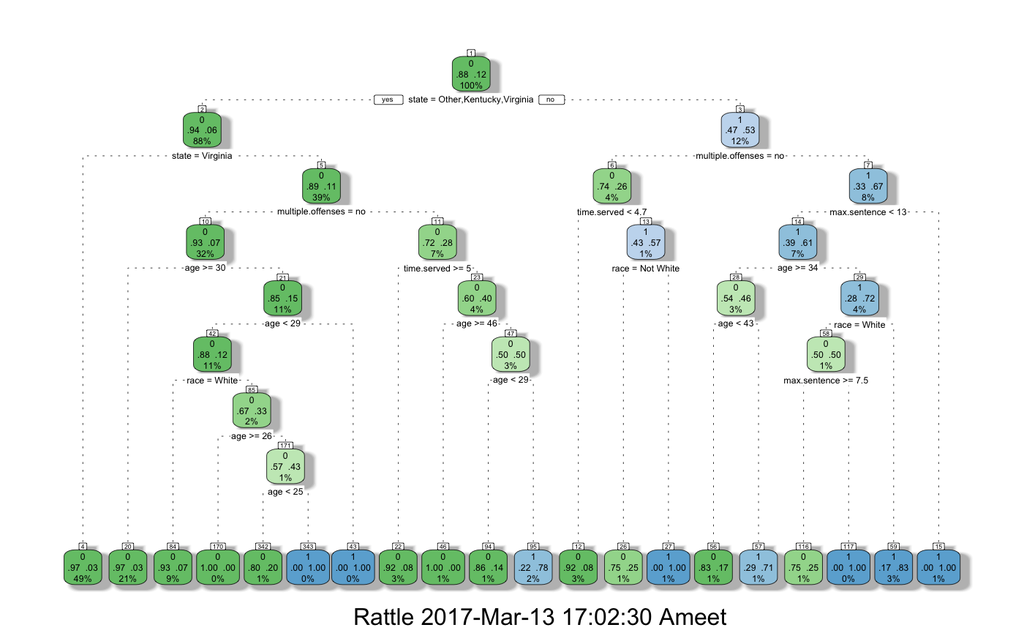

```r
fancyRpartPlot(tree)
```

```r
predTree = predict(tree,newdata=test,type="class")
```

##### Confusion matrix, Accuracy, Specificity and Sensitivity of the tree Model

Accuracy is 85%

Specificity is 91%

Sensitivity is 43%

```r
x = table(test$violator,predTree);x
```

```
   predTree
      0   1
  0 163  16
  1  13  10
```

```r
accuracy = sum(x[1,1],x[2,2])/nrow(test); accuracy
```

```
[1] 0.8564356
```

```r
specificity = x[1,1]/sum(x[1,1],x[1,2]); specificity
```

```
[1] 0.9106145
```

```r
sensitivity = x[2,2]/sum(x[2,1],x[2,2]); sensitivity
```

```
[1] 0.4347826
```

##### Construct ROC curve for the tree Model to select the best threshold

```r
predTreeProb = predict(tree,newdata=test,type="prob")
ROCRpred = prediction(predTreeProb[,2],test$violator)
as.numeric(performance(ROCRpred,"auc")@y.values) # auc measure
```

```
[1] 0.8160068
```

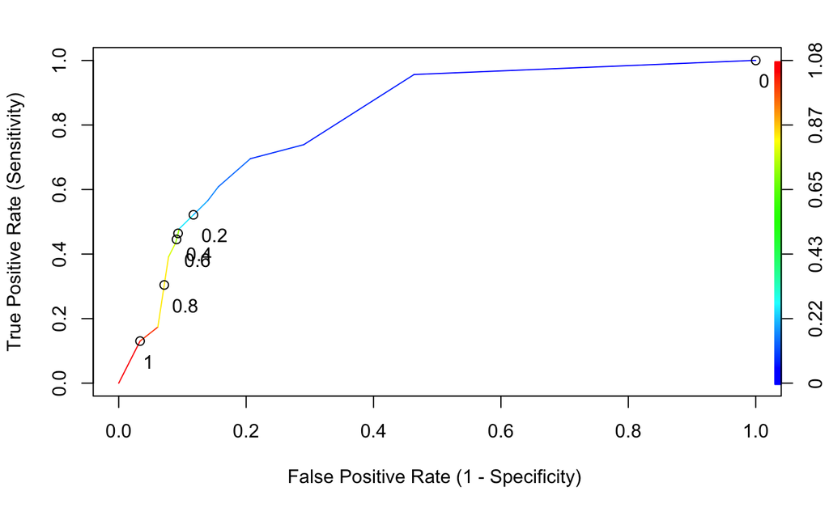

```r
## construct plot
ROCRperf = performance(ROCRpred,"tpr","fpr")
plot(ROCRperf,colorize=TRUE,print.cutoffs.at=seq(0,1,0.2),text.adj=c(-0.3,2),xlab="False Positive Rate (1 - Specificity) ",ylab="True Positive Rate (Sensitivity)") # color coded and annotated ROC curve
```

##### Conclusion

The decision to select one model over the other models would depend on whether the business needs a model with low “False Positive Rate” (1- Specificity) or high “True Positive Rate” (Sensitivity) metric.

In the parole dataset, since the focus is on lower False Positive Rate metric, the statistical model with the higher Specificity metric would be preferred.

The Logistic Regression model performs better than the Tree model in this scenario.